# Freestyle #1

Tim Riffe

June 6, 2019

# Freestyle demography

It’s important to mess around with code and data in an unstructured way. That is how we generate mistakes, fix them, and cause learning to happen. Let’s internalize some of the things we’ve seen in class, but on a fresh dataset that I’ve never seen, using methods I’m not entirely familiar with, etc. The goal will be to produce some visualizations that are geared toward better communication. Fancy if they need to be, simple where possible.

Let’s start by bringing in Prof. Rau’s code into a markdown file, annotating it, but not spending any time on theory. This was loosely narrated. You’ve seen it before. Now let’s do something with that final smoking by sex model.

Load packages

```r
library(ggplot2)
library(tidyverse)
library(survival)
library(broom)
```

This is the original data prep, re-written in tidy code, targetting only the `datasmoking` object. A single *verbalization* of the data processing steps. loading in the data takes the same amount of time, but I suppose the rest executes a bit faster, not that we care much about that. No intermediate data objects are created.

```r
load("SurvivalDataLarge.zip") # loading the data set. Might take a while...

# 1) select rows using filter()
datasmoking <- NHIS %>%
    filter(MORTELIG == 1 & BIRTHYR < 9000 & SMOKEV > 0) %>%
# 2) column coding and creation:
    mutate(  # column coding and creation:
           ENTRY = AGE,
           STATUS = ifelse(MORTSTAT == 2, 0, 1),
           EXITYEAR = ifelse(STATUS == 0,2015,MORTDODY),
           EXITQUARTER = ifelse(MORTDODQ == 9, 4, MORTDODQ),
           approxexitmonth = EXITQUARTER * 3 - 1,
           EXITAGE = ifelse(approxexitmonth > BIRTHMO,
                            EXITYEAR - BIRTHYR,
                            ifelse(approxexitmonth < BIRTHMO,
                                 EXITYEAR - BIRTHYR - 1,
                                 EXITYEAR - BIRTHYR - sample(c(0, 1), size = 1))),
           EXITAGE2 = ifelse(EXITAGE == ENTRY, EXITAGE + 0.5, EXITAGE  ),
           geschlecht = as.factor(SEX), # need sex as factor its strata
           geschlecht = relevel(geschlecht, ref = 2),
           smoker = ifelse(SMOKEV == 1,"Neversmoker",
                        ifelse(SMOKEV == 2, "Smoked100", "ResidualCategory")),
           smoker = as.factor(smoker),
           smoker = relevel(smoker, ref="Neversmoker")
                  ) %>%
# filter again using newly made column
    filter(EXITAGE >= ENTRY)

# get rid of the big piece of data...
rm(NHIS);gc()
```

```
##            used  (Mb) gc trigger   (Mb)  max used   (Mb)
## Ncells  2969607 158.6    8387957  448.0   4488945  239.8
## Vcells 46509590 354.9  182595470 1393.1 207580685 1583.8
```

```r
# Note, Surv doesn't have a data argument: it wants
# its inputs as vectors...
s.obj.smoke <- Surv(time = datasmoking$ENTRY,
                    time2 = datasmoking$EXITAGE2,
                    event = datasmoking$STATUS)

# now controlling for sex
coxsmokesex <- coxph(s.obj.smoke ~ smoker + geschlecht,
                     data = datasmoking,
                     model = TRUE)

# newdata to predict for, needs to have all the original columns
# given to Surv() and to coxph, apparently
newdata <- expand.grid(time = 19,
            time2 = 20,
            event = 1,
            geschlecht = unique(datasmoking$geschlecht),
            smoker = unique(datasmoking$smoker))
# survfit predicts for each strata, but it makes an awful complicated list,
# so we first tidy it, but there is some extra book keeping to do. Ugly ugly code
# and not worth internalizing all this, especially the quoted text pieces, which
# are ugly and ad hoc. This isn't exactly selling survfit + broom

coxstrata <- survfit(coxsmokesex, newdata = newdata) %>%
         tidy %>%
    gather(key = "lx", value = "value", -time, -n.risk,-n.event,-n.censor) %>%
    mutate(strata = as.integer(str_extract(lx, "[[0-9]]")),
           lx = str_extract(lx, "[[a-z]]+.[[a-z]]*"),
           id = 1:n()) %>%
    select(time, lx, strata, value) %>%
    spread(lx, value) %>%
    mutate(sex = ifelse(strata %% 2 == 0,"male","female"),
           smoker = ifelse(strata %in% c(1,2), "Neversmoker",
                        ifelse(strata %in% c(3,4), "Smoked100","Residual")))
```

Note: `survfit` produces knarly list output, but one of the elements is `haz`, which is a matrix where rows are `time` and columns are `strata`, but they are unfortunately unlabelled. There are other ways to just turn that object into something useful right away, but these exit the tidyverse for the most part. Can demonstrate if you like.

Now we have 6 survival curves, one for each sex and smoking status. Let’s convert each to `e(18)`. To do so, note that the curves start at 18.5, so we can assume age 18 has a value of 1.

```r
e18 <- coxstrata  %>%  group_by(sex,smoker) %>%
    summarize(ex = (sum(estimate.) + 1) / 2)
e18
```

```
## # A tibble: 6 x 3
## # Groups:   sex [2]
##   sex    smoker         ex
##   <chr>  <chr>       <dbl>
## 1 female Neversmoker  62.2
## 2 female Residual     59.6
## 3 female Smoked100    57.7
## 4 male   Neversmoker  59.5
## 5 male   Residual     56.7
## 6 male   Smoked100    54.7
```

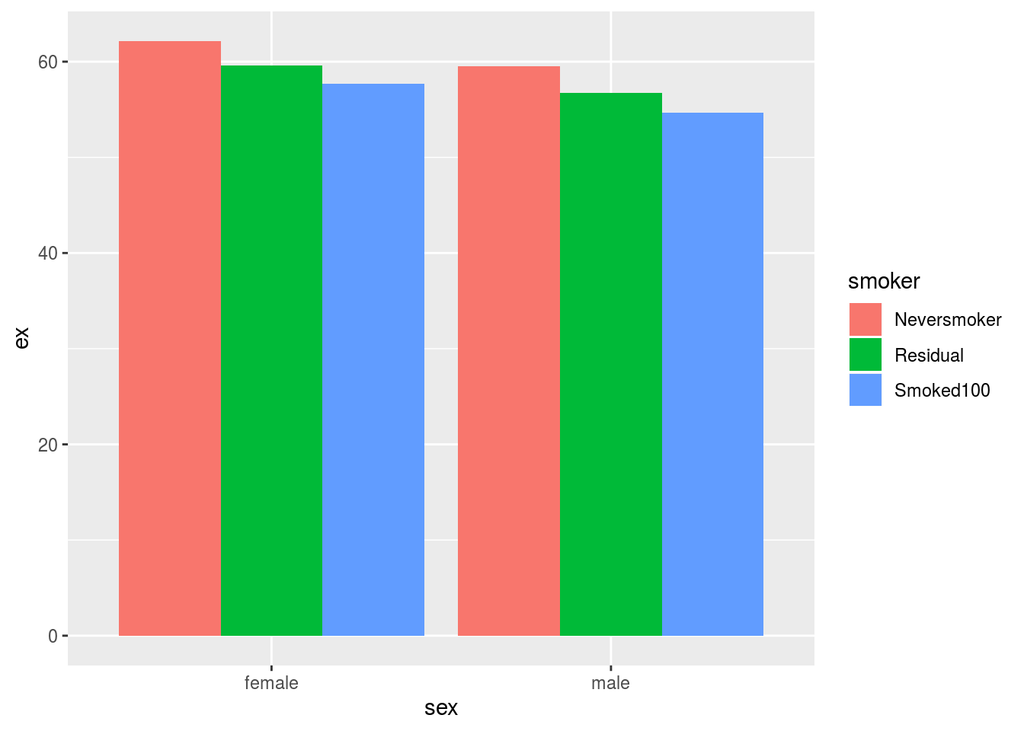

```r
ggplot(e18, mapping = aes(x = sex, y = ex, fill = smoker)) +
    geom_col(position = "dodge")
```

```r
sf <- survfit(coxsmokesex, newdata = newdata)
lx <- sf$surv
rownames(lx) <- sf$time
colnames(lx) <- paste(newdata$smoker, newdata$geschlecht, sep = "_")

library(reshape2)
lx <- melt(lx, value.name = "lx", varnames = c("Age", "Strata")) %>%
      separate(lx, col = Strata, into = c("smoker", "sex"))
```

# initial re-do using the `lung` dataset:

Hang on, let’s do this for a properly working example. Then I’ll go back and fix the one above, I swear.

```r
glimpse(lung)
```

```
## Observations: 228
## Variables: 10
## $ inst      <dbl> 3, 3, 3, 5, 1, 12, 7, 11, 1, 7, 6, 16, 11, 21, 12, 1, …
## $ time      <dbl> 306, 455, 1010, 210, 883, 1022, 310, 361, 218, 166, 17…
## $ status    <dbl> 2, 2, 1, 2, 2, 1, 2, 2, 2, 2, 2, 2, 2, 2, 2, 2, 2, 2, …
## $ age       <dbl> 74, 68, 56, 57, 60, 74, 68, 71, 53, 61, 57, 68, 68, 60…
## $ sex       <dbl> 1, 1, 1, 1, 1, 1, 2, 2, 1, 1, 1, 2, 2, 1, 1, 1, 1, 1, …
## $ ph.ecog   <dbl> 1, 0, 0, 1, 0, 1, 2, 2, 1, 2, 1, 2, 1, NA, 1, 1, 1, 2,…
## $ ph.karno  <dbl> 90, 90, 90, 90, 100, 50, 70, 60, 70, 70, 80, 70, 90, 6…
## $ pat.karno <dbl> 100, 90, 90, 60, 90, 80, 60, 80, 80, 70, 80, 70, 90, 7…
## $ meal.cal  <dbl> 1175, 1225, NA, 1150, NA, 513, 384, 538, 825, 271, 102…
## $ wt.loss   <dbl> NA, 15, 15, 11, 0, 0, 10, 1, 16, 34, 27, 23, 5, 32, 60…
```

```r
out_cph <- coxph(Surv(time, status) ~ age + sex, data = lung, method="breslow", model=TRUE)
out_fit  <- survfit(out_cph)
out_tidy <- tidy(out_fit)
out_tidy
```

```
## # A tibble: 186 x 8
##     time n.risk n.event n.censor estimate std.error conf.high conf.low
##    <dbl>  <dbl>   <dbl>    <dbl>    <dbl>     <dbl>     <dbl>    <dbl>
##  1     5    228       1        0    0.996   0.00419     1        0.988
##  2    11    227       3        0    0.983   0.00841     1.000    0.967
##  3    12    224       1        0    0.979   0.00944     0.997    0.961
##  4    13    223       2        0    0.971   0.0112      0.992    0.950
##  5    15    221       1        0    0.967   0.0121      0.990    0.944
##  6    26    220       1        0    0.962   0.0129      0.987    0.938
##  7    30    219       1        0    0.958   0.0136      0.984    0.933
##  8    31    218       1        0    0.954   0.0143      0.981    0.927
##  9    53    217       2        0    0.945   0.0157      0.975    0.917
## 10    54    215       1        0    0.941   0.0163      0.972    0.911
## # … with 176 more rows
```

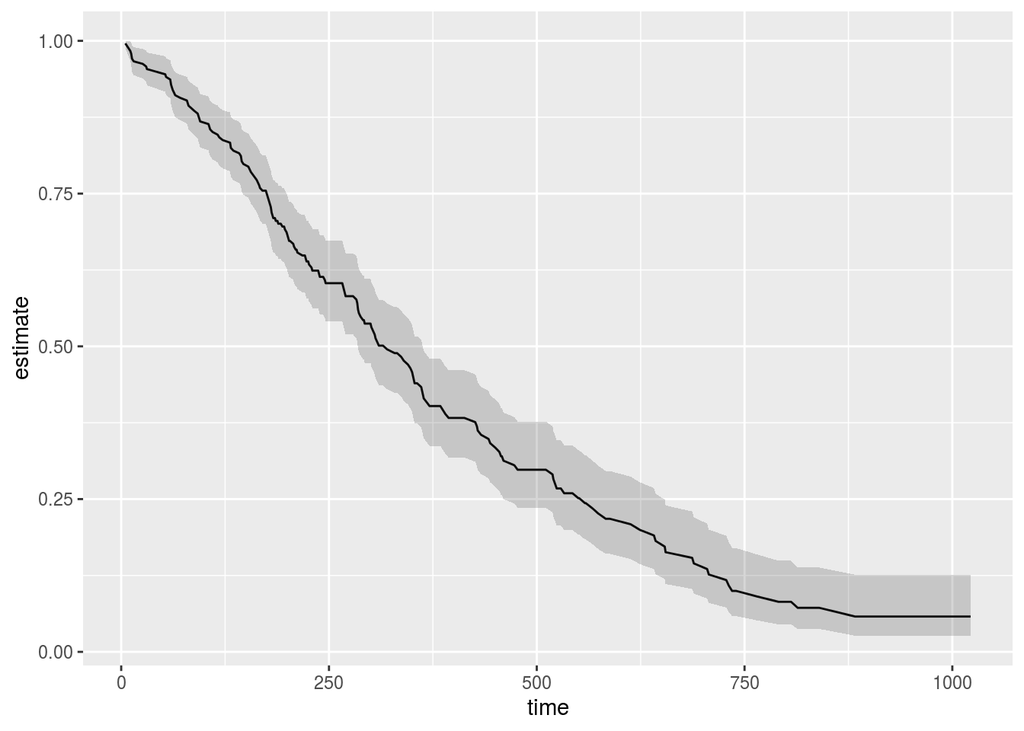

```r
p <- ggplot(out_tidy, mapping = aes(x = time,
                                    y = estimate,
                                    ymin = conf.low,
                                    ymax = conf.high))
p + geom_line() +
    geom_ribbon(alpha = .2)
```

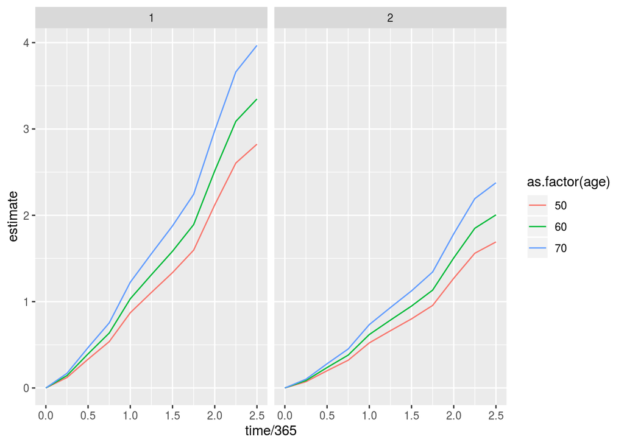

```r
newdata <- expand.grid(time = seq(0,2.5,by = .25) * 365,
                       sex = c(1,2),
                       age = c(50,60,70),
                       status = 0)

newdata$estimate <- predict(out_cph, newdata = newdata, type = "expected")

p <- ggplot(newdata, mapping = aes(x = time / 365,
                              y = estimate, color = as.factor(age)))
p + geom_line() + facet_wrap(~sex)
```

Now let’s do some dplyr magic to get all six expectancies, using the lifetable approach.

```r
newdata <- newdata %>% group_by(sex, age) %>%
    mutate(x = age + time / 365,
           haz = c(diff(estimate),5),
           int = .25,
           ax = int / 2,
           qx = (int * haz) / (1 + (int - ax) * haz), # correction 8-Aug
           lx = cumprod(1-qx),
           dx = c(-diff(lx),lx[length(lx)]),
           Lx = int * lx - (int - ax) * dx,
           Tx = rev(cumsum(rev(Lx))),
           ex = Tx / lx
    ) %>% ungroup()

newdata
```

```
## # A tibble: 66 x 15
##     time   sex   age status estimate     x   haz   int    ax     qx    lx
##    <dbl> <dbl> <dbl>  <dbl>    <dbl> <dbl> <dbl> <dbl> <dbl>  <dbl> <dbl>
##  1   0       1    50      0    0      50   0.121  0.25 0.125 0.0297 0.970
##  2  91.2     1    50      0    0.121  50.2 0.213  0.25 0.125 0.0518 0.920
##  3 182.      1    50      0    0.333  50.5 0.203  0.25 0.125 0.0495 0.875
##  4 274.      1    50      0    0.536  50.8 0.336  0.25 0.125 0.0805 0.804
##  5 365       1    50      0    0.872  51   0.235  0.25 0.125 0.0571 0.758
##  6 456.      1    50      0    1.11   51.2 0.230  0.25 0.125 0.0558 0.716
##  7 548.      1    50      0    1.34   51.5 0.260  0.25 0.125 0.0629 0.671
##  8 639.      1    50      0    1.60   51.8 0.525  0.25 0.125 0.123  0.588
##  9 730       1    50      0    2.12   52   0.484  0.25 0.125 0.114  0.521
## 10 821.      1    50      0    2.61   52.2 0.218  0.25 0.125 0.0531 0.493
## # … with 56 more rows, and 4 more variables: dx <dbl>, Lx <dbl>, Tx <dbl>,
## #   ex <dbl>
```

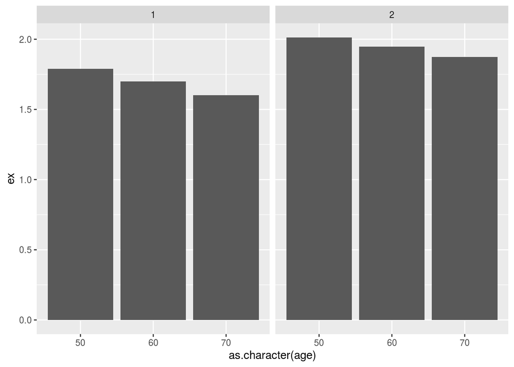

```r
ggplot(subset(newdata, time == 0), mapping = aes(y = ex, x = as.character(age))) +
    geom_col() + facet_wrap(~sex)
```

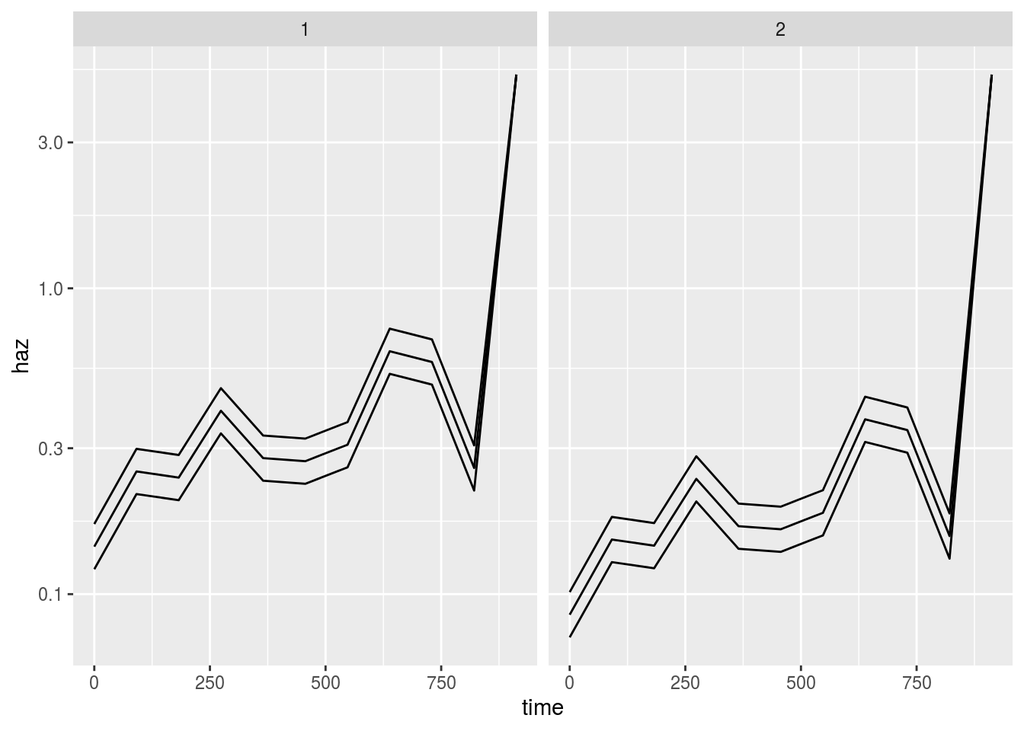

```r
ggplot(newdata, mapping = aes(y = haz, x = time, group = age)) +
    geom_line() + facet_wrap(~sex) + scale_y_log10()
```

This was a oncye-off redux of the pipeline into old-fashioned greedy coding style

```r
coxstrata <- survfit(coxsmokesex, newdata = newdata)
coxstrata <- tidy(coxstrata)
coxstrata <- gather(coxstrata, key = "lx", value = "value", -time, -n.risk,-n.event,-n.censor)
coxstrata <- mutate(coxstrata, strata = as.integer(str_extract(lx, "[[0-9]]")),
           lx = str_extract(lx, "[[a-z]]+.[[a-z]]*"),
           id = 1:n())
```

Testing some more for `survexp()`

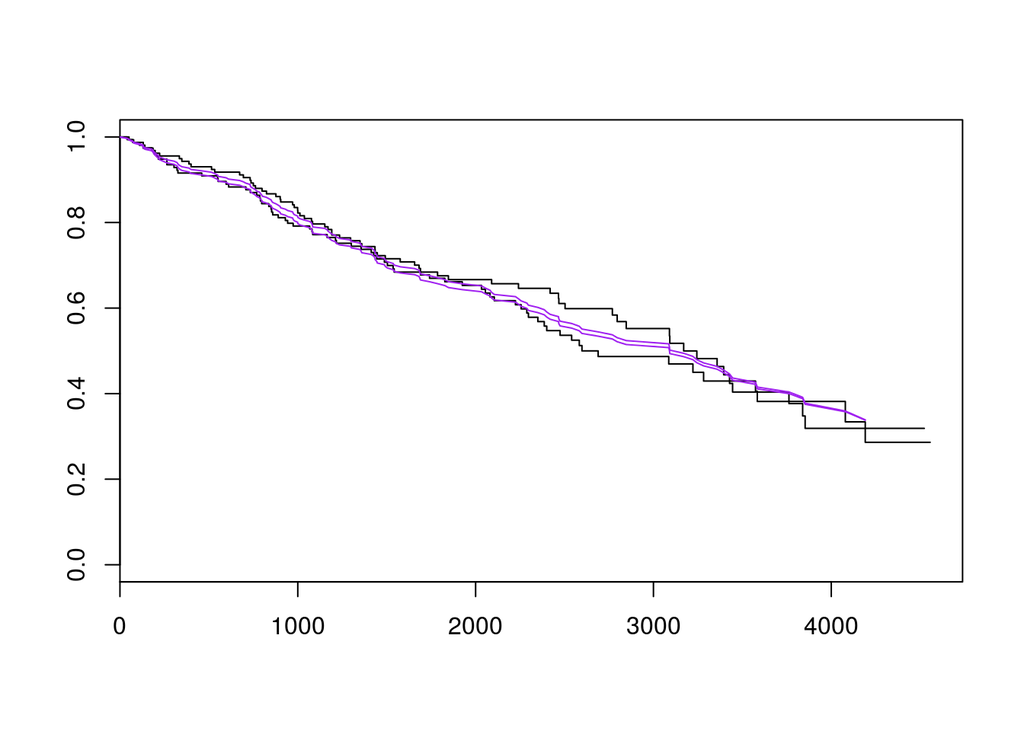

```r
library(survival)
pfit <-coxph(Surv(time,status>0) ~ trt + log(bili) + log(protime) + age +
                platelet, data=pbc)
plot(survfit(Surv(time, status>0) ~ trt, data=pbc), mark.time=FALSE)
lines(survexp( ~ trt, ratetable=pfit, data=pbc), col='purple')
```

```r
survexp( ~ trt, ratetable=pfit, data=pbc)
```

```
## Call:
## survexp(formula = ~trt, data = pbc, ratetable = pfit)
##
##
##  time nrisk1 nrisk2 trt=1 trt=2
##    41    156    152 0.997 0.997
##    51    156    152 0.994 0.993
##    71    156    152 0.991 0.989
##    77    156    152 0.988 0.986
##   110    156    152 0.985 0.982
##   130    156    152 0.981 0.979
##   131    156    152 0.978 0.975
##   140    156    152 0.975 0.971
##   179    156    152 0.972 0.968
##   186    156    152 0.969 0.964
```

[output cut: 130 more lines]